# Risk Factor Analysis

## Outcome Variable

**Outcome Variable:** swasted

## Predictor Variables

**Intervention Variable:** hhwealth_quart

**Adjustment Set:**

- arm
- sex
- W_mage
- meducyrs
- feducyrs
- W_gagebrth
- W_birthwt
- W_birthlen
- W_nchldlt5
- W_parity
- delta_W_mage
- delta_meducyrs
- delta_feducyrs
- delta_W_gagebrth
- delta_W_birthwt
- delta_W_birthlen
- delta_W_nchldlt5
- delta_W_parity

## Stratifying Variables

The analysis was stratified on these variable(s):

- agecat
- studyid
- country

## Data Summary

| agecat | studyid | country | hhwealth_quart | swasted | n_cell | n |
| --- | --- | --- | --- | --- | --- | --- |
| Birth | ki0047075b-MAL-ED | BANGLADESH | Wealth Q4 | 0 | 21 | 76 |
| Birth | ki0047075b-MAL-ED | BANGLADESH | Wealth Q4 | 1 | 0 | 76 |
| Birth | ki0047075b-MAL-ED | BANGLADESH | Wealth Q1 | 0 | 17 | 76 |
| Birth | ki0047075b-MAL-ED | BANGLADESH | Wealth Q1 | 1 | 0 | 76 |
| Birth | ki0047075b-MAL-ED | BANGLADESH | Wealth Q2 | 0 | 16 | 76 |
| Birth | ki0047075b-MAL-ED | BANGLADESH | Wealth Q2 | 1 | 2 | 76 |
| Birth | ki0047075b-MAL-ED | BANGLADESH | Wealth Q3 | 0 | 20 | 76 |
| Birth | ki0047075b-MAL-ED | BANGLADESH | Wealth Q3 | 1 | 0 | 76 |
| Birth | ki0047075b-MAL-ED | INDIA | Wealth Q4 | 0 | 11 | 54 |
| Birth | ki0047075b-MAL-ED | INDIA | Wealth Q4 | 1 | 0 | 54 |
| Birth | ki0047075b-MAL-ED | INDIA | Wealth Q1 | 0 | 14 | 54 |
| Birth | ki0047075b-MAL-ED | INDIA | Wealth Q1 | 1 | 3 | 54 |
| Birth | ki0047075b-MAL-ED | INDIA | Wealth Q2 | 0 | 15 | 54 |
| Birth | ki0047075b-MAL-ED | INDIA | Wealth Q2 | 1 | 0 | 54 |
| Birth | ki0047075b-MAL-ED | INDIA | Wealth Q3 | 0 | 11 | 54 |
| Birth | ki0047075b-MAL-ED | INDIA | Wealth Q3 | 1 | 0 | 54 |
| Birth | ki0047075b-MAL-ED | NEPAL | Wealth Q4 | 0 | 9 | 30 |
| Birth | ki0047075b-MAL-ED | NEPAL | Wealth Q4 | 1 | 0 | 30 |
| Birth | ki0047075b-MAL-ED | NEPAL | Wealth Q1 | 0 | 8 | 30 |
| Birth | ki0047075b-MAL-ED | NEPAL | Wealth Q1 | 1 | 0 | 30 |
| Birth | ki0047075b-MAL-ED | NEPAL | Wealth Q2 | 0 | 5 | 30 |
| Birth | ki0047075b-MAL-ED | NEPAL | Wealth Q2 | 1 | 1 | 30 |
| Birth | ki0047075b-MAL-ED | NEPAL | Wealth Q3 | 0 | 7 | 30 |
| Birth | ki0047075b-MAL-ED | NEPAL | Wealth Q3 | 1 | 0 | 30 |
| Birth | ki0047075b-MAL-ED | PERU | Wealth Q4 | 0 | 10 | 36 |
| Birth | ki0047075b-MAL-ED | PERU | Wealth Q4 | 1 | 0 | 36 |
| Birth | ki0047075b-MAL-ED | PERU | Wealth Q1 | 0 | 9 | 36 |
| Birth | ki0047075b-MAL-ED | PERU | Wealth Q1 | 1 | 0 | 36 |
| Birth | ki0047075b-MAL-ED | PERU | Wealth Q2 | 0 | 9 | 36 |
| Birth | ki0047075b-MAL-ED | PERU | Wealth Q2 | 1 | 0 | 36 |

[output cut: 346 more lines]

The following strata were considered:

- agecat: 24 months, studyid: ki0047075b-MAL-ED, country: BANGLADESH
- agecat: 24 months, studyid: ki0047075b-MAL-ED, country: INDIA
- agecat: 24 months, studyid: ki0047075b-MAL-ED, country: NEPAL
- agecat: 24 months, studyid: ki0047075b-MAL-ED, country: PERU
- agecat: 24 months, studyid: ki0047075b-MAL-ED, country: SOUTH AFRICA
- agecat: 24 months, studyid: ki0047075b-MAL-ED, country: TANZANIA, UNITED REPUBLIC OF
- agecat: 24 months, studyid: ki1000108-CMC-V-BCS-2002, country: INDIA
- agecat: 24 months, studyid: ki1000108-IRC, country: INDIA
- agecat: 24 months, studyid: ki1017093b-PROVIDE, country: BANGLADESH
- agecat: 24 months, studyid: ki1066203-TanzaniaChild2, country: TANZANIA, UNITED REPUBLIC OF
- agecat: 24 months, studyid: ki1113344-GMS-Nepal, country: NEPAL
- agecat: 24 months, studyid: ki1114097-CONTENT, country: PERU
- agecat: 24 months, studyid: ki1135781-COHORTS, country: GUATEMALA
- agecat: 24 months, studyid: ki1135781-COHORTS, country: PHILIPPINES
- agecat: 24 months, studyid: ki1148112-LCNI-5, country: MALAWI
- agecat: 24 months, studyid: kiGH5241-JiVitA-3, country: BANGLADESH
- agecat: 24 months, studyid: kiGH5241-JiVitA-4, country: BANGLADESH
- agecat: 6 months, studyid: ki0047075b-MAL-ED, country: BANGLADESH
- agecat: 6 months, studyid: ki0047075b-MAL-ED, country: INDIA
- agecat: 6 months, studyid: ki0047075b-MAL-ED, country: NEPAL
- agecat: 6 months, studyid: ki0047075b-MAL-ED, country: PERU
- agecat: 6 months, studyid: ki0047075b-MAL-ED, country: SOUTH AFRICA
- agecat: 6 months, studyid: ki0047075b-MAL-ED, country: TANZANIA, UNITED REPUBLIC OF
- agecat: 6 months, studyid: ki1000108-CMC-V-BCS-2002, country: INDIA
- agecat: 6 months, studyid: ki1000108-IRC, country: INDIA
- agecat: 6 months, studyid: ki1017093b-PROVIDE, country: BANGLADESH
- agecat: 6 months, studyid: ki1066203-TanzaniaChild2, country: TANZANIA, UNITED REPUBLIC OF
- agecat: 6 months, studyid: ki1113344-GMS-Nepal, country: NEPAL
- agecat: 6 months, studyid: ki1114097-CONTENT, country: PERU
- agecat: 6 months, studyid: ki1135781-COHORTS, country: GUATEMALA
- agecat: 6 months, studyid: ki1135781-COHORTS, country: PHILIPPINES
- agecat: 6 months, studyid: ki1148112-LCNI-5, country: MALAWI
- agecat: 6 months, studyid: kiGH5241-JiVitA-3, country: BANGLADESH
- agecat: 6 months, studyid: kiGH5241-JiVitA-4, country: BANGLADESH
- agecat: Birth, studyid: ki0047075b-MAL-ED, country: BANGLADESH
- agecat: Birth, studyid: ki0047075b-MAL-ED, country: INDIA
- agecat: Birth, studyid: ki0047075b-MAL-ED, country: NEPAL
- agecat: Birth, studyid: ki0047075b-MAL-ED, country: PERU
- agecat: Birth, studyid: ki0047075b-MAL-ED, country: SOUTH AFRICA
- agecat: Birth, studyid: ki0047075b-MAL-ED, country: TANZANIA, UNITED REPUBLIC OF
- agecat: Birth, studyid: ki1000108-CMC-V-BCS-2002, country: INDIA
- agecat: Birth, studyid: ki1000108-IRC, country: INDIA
- agecat: Birth, studyid: ki1114097-CONTENT, country: PERU
- agecat: Birth, studyid: ki1135781-COHORTS, country: GUATEMALA
- agecat: Birth, studyid: ki1135781-COHORTS, country: PHILIPPINES
- agecat: Birth, studyid: kiGH5241-JiVitA-3, country: BANGLADESH
- agecat: Birth, studyid: kiGH5241-JiVitA-4, country: BANGLADESH

### Dropped Strata

Some strata were dropped due to rare outcomes:

- agecat: Birth, studyid: ki0047075b-MAL-ED, country: BANGLADESH
- agecat: Birth, studyid: ki0047075b-MAL-ED, country: INDIA
- agecat: Birth, studyid: ki0047075b-MAL-ED, country: NEPAL
- agecat: Birth, studyid: ki0047075b-MAL-ED, country: PERU
- agecat: Birth, studyid: ki0047075b-MAL-ED, country: SOUTH AFRICA
- agecat: Birth, studyid: ki0047075b-MAL-ED, country: TANZANIA, UNITED REPUBLIC OF
- agecat: Birth, studyid: ki1000108-CMC-V-BCS-2002, country: INDIA
- agecat: Birth, studyid: ki1114097-CONTENT, country: PERU
- agecat: Birth, studyid: kiGH5241-JiVitA-4, country: BANGLADESH
- agecat: 6 months, studyid: ki0047075b-MAL-ED, country: BANGLADESH
- agecat: 6 months, studyid: ki0047075b-MAL-ED, country: INDIA
- agecat: 6 months, studyid: ki0047075b-MAL-ED, country: NEPAL
- agecat: 6 months, studyid: ki0047075b-MAL-ED, country: PERU
- agecat: 6 months, studyid: ki0047075b-MAL-ED, country: SOUTH AFRICA
- agecat: 6 months, studyid: ki0047075b-MAL-ED, country: TANZANIA, UNITED REPUBLIC OF
- agecat: 6 months, studyid: ki1000108-CMC-V-BCS-2002, country: INDIA
- agecat: 6 months, studyid: ki1000108-IRC, country: INDIA
- agecat: 6 months, studyid: ki1017093b-PROVIDE, country: BANGLADESH
- agecat: 6 months, studyid: ki1066203-TanzaniaChild2, country: TANZANIA, UNITED REPUBLIC OF
- agecat: 6 months, studyid: ki1113344-GMS-Nepal, country: NEPAL
- agecat: 6 months, studyid: ki1114097-CONTENT, country: PERU
- agecat: 6 months, studyid: ki1135781-COHORTS, country: GUATEMALA
- agecat: 6 months, studyid: ki1148112-LCNI-5, country: MALAWI
- agecat: 6 months, studyid: kiGH5241-JiVitA-4, country: BANGLADESH
- agecat: 24 months, studyid: ki0047075b-MAL-ED, country: BANGLADESH
- agecat: 24 months, studyid: ki0047075b-MAL-ED, country: INDIA
- agecat: 24 months, studyid: ki0047075b-MAL-ED, country: NEPAL
- agecat: 24 months, studyid: ki0047075b-MAL-ED, country: PERU
- agecat: 24 months, studyid: ki0047075b-MAL-ED, country: SOUTH AFRICA
- agecat: 24 months, studyid: ki0047075b-MAL-ED, country: TANZANIA, UNITED REPUBLIC OF
- agecat: 24 months, studyid: ki1000108-CMC-V-BCS-2002, country: INDIA
- agecat: 24 months, studyid: ki1000108-IRC, country: INDIA
- agecat: 24 months, studyid: ki1017093b-PROVIDE, country: BANGLADESH
- agecat: 24 months, studyid: ki1066203-TanzaniaChild2, country: TANZANIA, UNITED REPUBLIC OF
- agecat: 24 months, studyid: ki1113344-GMS-Nepal, country: NEPAL
- agecat: 24 months, studyid: ki1114097-CONTENT, country: PERU
- agecat: 24 months, studyid: ki1135781-COHORTS, country: GUATEMALA
- agecat: 24 months, studyid: ki1135781-COHORTS, country: PHILIPPINES
- agecat: 24 months, studyid: ki1148112-LCNI-5, country: MALAWI

## Methods Detail

We’re interested in the causal parameters $E[Y_a]$ for all values of $a \in \mathcal{A}$. These parameters represent the mean outcome if, possibly contrary to fact, we intervened to set all units to have $A=a$. Under the randomization and positivity assumptions, these are identified by the statistical parameters $\psi_a=E_W[E_{Y|A,W}(Y|A=a,W)]$. In addition, we’re interested in the mean of $Y$, $E[Y]$ under no intervention (the observed mean). We will estimate these parameters by using SuperLearner to fit the relevant likelihood factors – $E_{Y|A,W}(Y|A=a,W)$ and $p(A=a|W)$, and then updating our likelihood fit using a joint TMLE.

For unadjusted analyses ($W=\{\}$), initial likelihoods were estimated using Lrnr_glm to estimate the simple $E(Y|A)$ and Lrnr_mean to estimate $p(A)$. For adjusted analyses, a small library containing Lrnr_glmnet, Lrnr_xgboost, and Lrnr_mean was used.

Having estimated these parameters, we will then use the delta method to estimate relative risks and attributable risks relative to a prespecified baseline level of $A$.

# Results Detail

## Results Plots

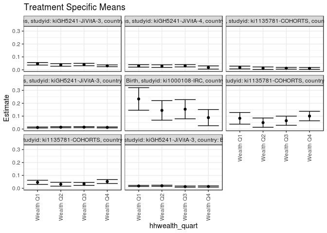

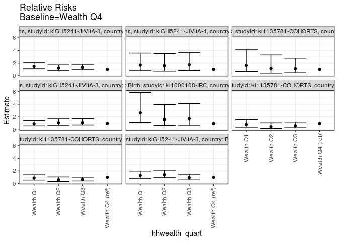

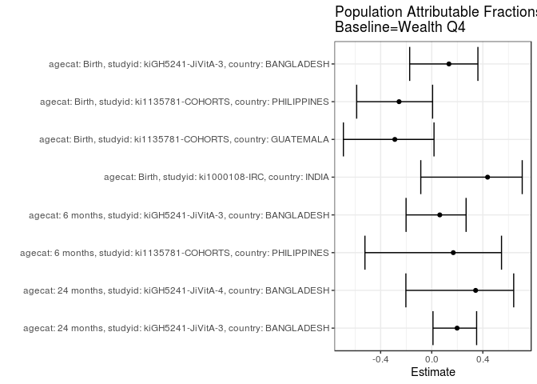

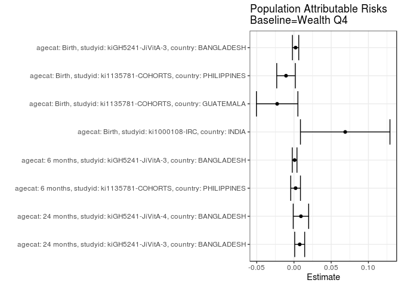

## Results Table

### Parameter: TSM

| agecat | studyid | country | intervention_level | baseline_level | estimate | ci_lower | ci_upper |
| --- | --- | --- | --- | --- | --- | --- | --- |
| Birth | ki1000108-IRC | INDIA | Wealth Q4 | NA | 0.0886076 | 0.0258514 | 0.1513638 |
| Birth | ki1000108-IRC | INDIA | Wealth Q1 | NA | 0.2333333 | 0.1458244 | 0.3208423 |
| Birth | ki1000108-IRC | INDIA | Wealth Q2 | NA | 0.1445783 | 0.0688105 | 0.2203461 |
| Birth | ki1000108-IRC | INDIA | Wealth Q3 | NA | 0.1538462 | 0.0796076 | 0.2280847 |
| Birth | ki1135781-COHORTS | GUATEMALA | Wealth Q4 | NA | 0.1007752 | 0.0640176 | 0.1375328 |
| Birth | ki1135781-COHORTS | GUATEMALA | Wealth Q1 | NA | 0.0833333 | 0.0381602 | 0.1285064 |
| Birth | ki1135781-COHORTS | GUATEMALA | Wealth Q2 | NA | 0.0496454 | 0.0137682 | 0.0855226 |
| Birth | ki1135781-COHORTS | GUATEMALA | Wealth Q3 | NA | 0.0645161 | 0.0291863 | 0.0998460 |
| Birth | ki1135781-COHORTS | PHILIPPINES | Wealth Q4 | NA | 0.0524284 | 0.0368973 | 0.0679594 |
| Birth | ki1135781-COHORTS | PHILIPPINES | Wealth Q1 | NA | 0.0461421 | 0.0300585 | 0.0622256 |
| Birth | ki1135781-COHORTS | PHILIPPINES | Wealth Q2 | NA | 0.0315187 | 0.0165374 | 0.0465000 |
| Birth | ki1135781-COHORTS | PHILIPPINES | Wealth Q3 | NA | 0.0340595 | 0.0224678 | 0.0456513 |
| Birth | kiGH5241-JiVitA-3 | BANGLADESH | Wealth Q4 | NA | 0.0140074 | 0.0091011 | 0.0189137 |
| Birth | kiGH5241-JiVitA-3 | BANGLADESH | Wealth Q1 | NA | 0.0180292 | 0.0135647 | 0.0224937 |
| Birth | kiGH5241-JiVitA-3 | BANGLADESH | Wealth Q2 | NA | 0.0196858 | 0.0153465 | 0.0240250 |
| Birth | kiGH5241-JiVitA-3 | BANGLADESH | Wealth Q3 | NA | 0.0130499 | 0.0085823 | 0.0175174 |
| 6 months | ki1135781-COHORTS | PHILIPPINES | Wealth Q4 | NA | 0.0107527 | 0.0033404 | 0.0181650 |
| 6 months | ki1135781-COHORTS | PHILIPPINES | Wealth Q1 | NA | 0.0175747 | 0.0067761 | 0.0283733 |
| 6 months | ki1135781-COHORTS | PHILIPPINES | Wealth Q2 | NA | 0.0123711 | 0.0025319 | 0.0222103 |
| 6 months | ki1135781-COHORTS | PHILIPPINES | Wealth Q3 | NA | 0.0121145 | 0.0049976 | 0.0192315 |
| 6 months | kiGH5241-JiVitA-3 | BANGLADESH | Wealth Q4 | NA | 0.0127894 | 0.0089538 | 0.0166250 |
| 6 months | kiGH5241-JiVitA-3 | BANGLADESH | Wealth Q1 | NA | 0.0122873 | 0.0084408 | 0.0161337 |
| 6 months | kiGH5241-JiVitA-3 | BANGLADESH | Wealth Q2 | NA | 0.0142481 | 0.0101081 | 0.0183881 |
| 6 months | kiGH5241-JiVitA-3 | BANGLADESH | Wealth Q3 | NA | 0.0146956 | 0.0106531 | 0.0187380 |
| 24 months | kiGH5241-JiVitA-3 | BANGLADESH | Wealth Q4 | NA | 0.0310532 | 0.0239068 | 0.0381997 |
| 24 months | kiGH5241-JiVitA-3 | BANGLADESH | Wealth Q1 | NA | 0.0467465 | 0.0367906 | 0.0567025 |
| 24 months | kiGH5241-JiVitA-3 | BANGLADESH | Wealth Q2 | NA | 0.0376867 | 0.0276625 | 0.0477108 |
| 24 months | kiGH5241-JiVitA-3 | BANGLADESH | Wealth Q3 | NA | 0.0407791 | 0.0313640 | 0.0501943 |
| 24 months | kiGH5241-JiVitA-4 | BANGLADESH | Wealth Q4 | NA | 0.0179040 | 0.0054789 | 0.0303292 |
| 24 months | kiGH5241-JiVitA-4 | BANGLADESH | Wealth Q1 | NA | 0.0301041 | 0.0205866 | 0.0396216 |
| 24 months | kiGH5241-JiVitA-4 | BANGLADESH | Wealth Q2 | NA | 0.0285958 | 0.0181445 | 0.0390471 |
| 24 months | kiGH5241-JiVitA-4 | BANGLADESH | Wealth Q3 | NA | 0.0312695 | 0.0224642 | 0.0400747 |

### Parameter: E(Y)

| agecat | studyid | country | intervention_level | baseline_level | estimate | ci_lower | ci_upper |
| --- | --- | --- | --- | --- | --- | --- | --- |
| Birth | ki1000108-IRC | INDIA | NA | NA | 0.1574344 | 0.1188345 | 0.1960344 |
| Birth | ki1135781-COHORTS | GUATEMALA | NA | NA | 0.0781893 | 0.0586874 | 0.0976912 |
| Birth | ki1135781-COHORTS | PHILIPPINES | NA | NA | 0.0417529 | 0.0344692 | 0.0490367 |
| Birth | kiGH5241-JiVitA-3 | BANGLADESH | NA | NA | 0.0161876 | 0.0138223 | 0.0185529 |
| 6 months | ki1135781-COHORTS | PHILIPPINES | NA | NA | 0.0129342 | 0.0086762 | 0.0171922 |
| 6 months | kiGH5241-JiVitA-3 | BANGLADESH | NA | NA | 0.0136505 | 0.0115778 | 0.0157231 |
| 24 months | kiGH5241-JiVitA-3 | BANGLADESH | NA | NA | 0.0387480 | 0.0344217 | 0.0430742 |
| 24 months | kiGH5241-JiVitA-4 | BANGLADESH | NA | NA | 0.0272727 | 0.0220640 | 0.0324815 |

### Parameter: RR

| agecat | studyid | country | intervention_level | baseline_level | estimate | ci_lower | ci_upper |
| --- | --- | --- | --- | --- | --- | --- | --- |
| Birth | ki1000108-IRC | INDIA | Wealth Q4 | Wealth Q4 | 1.0000000 | 1.0000000 | 1.000000 |
| Birth | ki1000108-IRC | INDIA | Wealth Q1 | Wealth Q4 | 2.6333330 | 1.1815568 | 5.868903 |
| Birth | ki1000108-IRC | INDIA | Wealth Q2 | Wealth Q4 | 1.6316693 | 0.6760758 | 3.937938 |
| Birth | ki1000108-IRC | INDIA | Wealth Q3 | Wealth Q4 | 1.7362635 | 0.7369189 | 4.090831 |
| Birth | ki1135781-COHORTS | GUATEMALA | Wealth Q4 | Wealth Q4 | 1.0000000 | 1.0000000 | 1.000000 |
| Birth | ki1135781-COHORTS | GUATEMALA | Wealth Q1 | Wealth Q4 | 0.8269231 | 0.4302403 | 1.589348 |
| Birth | ki1135781-COHORTS | GUATEMALA | Wealth Q2 | Wealth Q4 | 0.4926350 | 0.2192618 | 1.106847 |
| Birth | ki1135781-COHORTS | GUATEMALA | Wealth Q3 | Wealth Q4 | 0.6401985 | 0.3315606 | 1.236136 |
| Birth | ki1135781-COHORTS | PHILIPPINES | Wealth Q4 | Wealth Q4 | 1.0000000 | 1.0000000 | 1.000000 |
| Birth | ki1135781-COHORTS | PHILIPPINES | Wealth Q1 | Wealth Q4 | 0.8800971 | 0.5575852 | 1.389153 |
| Birth | ki1135781-COHORTS | PHILIPPINES | Wealth Q2 | Wealth Q4 | 0.6011768 | 0.3437144 | 1.051494 |
| Birth | ki1135781-COHORTS | PHILIPPINES | Wealth Q3 | Wealth Q4 | 0.6496392 | 0.4142788 | 1.018713 |
| Birth | kiGH5241-JiVitA-3 | BANGLADESH | Wealth Q4 | Wealth Q4 | 1.0000000 | 1.0000000 | 1.000000 |
| Birth | kiGH5241-JiVitA-3 | BANGLADESH | Wealth Q1 | Wealth Q4 | 1.2871225 | 0.8367578 | 1.979885 |
| Birth | kiGH5241-JiVitA-3 | BANGLADESH | Wealth Q2 | Wealth Q4 | 1.4053869 | 0.9312313 | 2.120969 |
| Birth | kiGH5241-JiVitA-3 | BANGLADESH | Wealth Q3 | Wealth Q4 | 0.9316413 | 0.5843470 | 1.485343 |
| 6 months | ki1135781-COHORTS | PHILIPPINES | Wealth Q4 | Wealth Q4 | 1.0000000 | 1.0000000 | 1.000000 |
| 6 months | ki1135781-COHORTS | PHILIPPINES | Wealth Q1 | Wealth Q4 | 1.6344464 | 0.6491256 | 4.115405 |
| 6 months | ki1135781-COHORTS | PHILIPPINES | Wealth Q2 | Wealth Q4 | 1.1505155 | 0.4016045 | 3.295993 |
| 6 months | ki1135781-COHORTS | PHILIPPINES | Wealth Q3 | Wealth Q4 | 1.1266520 | 0.4554533 | 2.786992 |
| 6 months | kiGH5241-JiVitA-3 | BANGLADESH | Wealth Q4 | Wealth Q4 | 1.0000000 | 1.0000000 | 1.000000 |
| 6 months | kiGH5241-JiVitA-3 | BANGLADESH | Wealth Q1 | Wealth Q4 | 0.9607382 | 0.6284195 | 1.468793 |
| 6 months | kiGH5241-JiVitA-3 | BANGLADESH | Wealth Q2 | Wealth Q4 | 1.1140570 | 0.7348961 | 1.688841 |
| 6 months | kiGH5241-JiVitA-3 | BANGLADESH | Wealth Q3 | Wealth Q4 | 1.1490436 | 0.7734284 | 1.707076 |
| 24 months | kiGH5241-JiVitA-3 | BANGLADESH | Wealth Q4 | Wealth Q4 | 1.0000000 | 1.0000000 | 1.000000 |
| 24 months | kiGH5241-JiVitA-3 | BANGLADESH | Wealth Q1 | Wealth Q4 | 1.5053671 | 1.1002236 | 2.059700 |
| 24 months | kiGH5241-JiVitA-3 | BANGLADESH | Wealth Q2 | Wealth Q4 | 1.2136144 | 0.8554543 | 1.721728 |
| 24 months | kiGH5241-JiVitA-3 | BANGLADESH | Wealth Q3 | Wealth Q4 | 1.3132002 | 0.9468075 | 1.821379 |
| 24 months | kiGH5241-JiVitA-4 | BANGLADESH | Wealth Q4 | Wealth Q4 | 1.0000000 | 1.0000000 | 1.000000 |
| 24 months | kiGH5241-JiVitA-4 | BANGLADESH | Wealth Q1 | Wealth Q4 | 1.6814154 | 0.7865918 | 3.594187 |
| 24 months | kiGH5241-JiVitA-4 | BANGLADESH | Wealth Q2 | Wealth Q4 | 1.5971699 | 0.7270999 | 3.508393 |
| 24 months | kiGH5241-JiVitA-4 | BANGLADESH | Wealth Q3 | Wealth Q4 | 1.7465043 | 0.8227781 | 3.707290 |

### Parameter: PAR

| agecat | studyid | country | intervention_level | baseline_level | estimate | ci_lower | ci_upper |
| --- | --- | --- | --- | --- | --- | --- | --- |
| Birth | ki1000108-IRC | INDIA | Wealth Q4 | NA | 0.0688268 | 0.0087091 | 0.1289445 |
| Birth | ki1135781-COHORTS | GUATEMALA | Wealth Q4 | NA | -0.0225859 | -0.0504264 | 0.0052547 |
| Birth | ki1135781-COHORTS | PHILIPPINES | Wealth Q4 | NA | -0.0106755 | -0.0231603 | 0.0018094 |
| Birth | kiGH5241-JiVitA-3 | BANGLADESH | Wealth Q4 | NA | 0.0021802 | -0.0020562 | 0.0064167 |
| 6 months | ki1135781-COHORTS | PHILIPPINES | Wealth Q4 | NA | 0.0021815 | -0.0043653 | 0.0087283 |
| 6 months | kiGH5241-JiVitA-3 | BANGLADESH | Wealth Q4 | NA | 0.0008611 | -0.0023066 | 0.0040287 |
| 24 months | kiGH5241-JiVitA-3 | BANGLADESH | Wealth Q4 | NA | 0.0076947 | 0.0009956 | 0.0143939 |
| 24 months | kiGH5241-JiVitA-4 | BANGLADESH | Wealth Q4 | NA | 0.0093687 | -0.0009914 | 0.0197288 |

### Parameter: PAF

| agecat | studyid | country | intervention_level | baseline_level | estimate | ci_lower | ci_upper |
| --- | --- | --- | --- | --- | --- | --- | --- |
| Birth | ki1000108-IRC | INDIA | Wealth Q4 | NA | 0.4371776 | -0.0857091 | 0.7082377 |
| Birth | ki1135781-COHORTS | GUATEMALA | Wealth Q4 | NA | -0.2888617 | -0.6914201 | 0.0178877 |
| Birth | ki1135781-COHORTS | PHILIPPINES | Wealth Q4 | NA | -0.2556816 | -0.5874418 | 0.0067438 |
| Birth | kiGH5241-JiVitA-3 | BANGLADESH | Wealth Q4 | NA | 0.1346861 | -0.1726143 | 0.3614540 |
| 6 months | ki1135781-COHORTS | PHILIPPINES | Wealth Q4 | NA | 0.1686636 | -0.5227820 | 0.5461463 |
| 6 months | kiGH5241-JiVitA-3 | BANGLADESH | Wealth Q4 | NA | 0.0630799 | -0.2008480 | 0.2690004 |
| 24 months | kiGH5241-JiVitA-3 | BANGLADESH | Wealth Q4 | NA | 0.1985838 | 0.0098405 | 0.3513491 |
| 24 months | kiGH5241-JiVitA-4 | BANGLADESH | Wealth Q4 | NA | 0.3435190 | -0.2023226 | 0.6415544 |